# TrabajoFinal

David M. Villalobo

2023-05-26

## Introducción

Las lascas y las laminas son piezas líticas productos de las técnicas de talla. La primera es una porción plana o curva extraida de un núcleo, y la segunda es una pieza alargada y delgada obtenida del desbaste y talla de un núcleo o de una lasca previa. Las estudiadas en este trabajo están hechas en obsidiana, un material perfecto por su dureza y la capacidad de mantener los bordes afilados.

La base de datos utilizada para este trabajo, obtenida de la página web “Comparative Archaeology Database”, presenta diferentes Laminas (blade) y Lascas (flake) de obsidiana, y cada una presenta una serie de variables características (Anchura, Grosor, Longitud y Peso). Para este trabajo he tenido en cuenta que la norma general sobre las laminas y las lascas, es que las laminas suelen ser dos veces más largas que anchas. En este trabajo buscaré si hay relación entre los diferentes parámetros arqueométricos con respecto a que un instrumento sea blade o flake.

## Importar base de datos

```r
library(readxl)
BaseDatosFinal <- read_excel(path = "BaseDatosFinal.xlsx")
```

## Primer Paso

En la variable Tipo, las opciones blade y flake son renombradas como 1 (blade) y 0 (flake). Esto nos ayudará para llevar a cabo modelos logísticos. Este proceso suele llevarse a cabo con variables categóricas como es en este caso.

```r
library(plyr)
BaseDatosFinal$Tipo <- mapvalues(BaseDatosFinal$Tipo, from = c("blade", "flake"), to = c(1,0))
```

## Segundo Paso

Realizo gráficos de distribución para poder tener una visión general de la variabilidad de los datos, ver patrones y valores atípicos. Para utilizar los códigos es necesario la librería de ggplot2. Los puntos que se muestran se distribuyen según las variables utilizadas. La función color = Tipo dentro de aes() nos permite hacer una diferenciación por colores de cada categoría de la variable Tipo. El color azul hace referencia a blade(1) y rojo es flake(0).

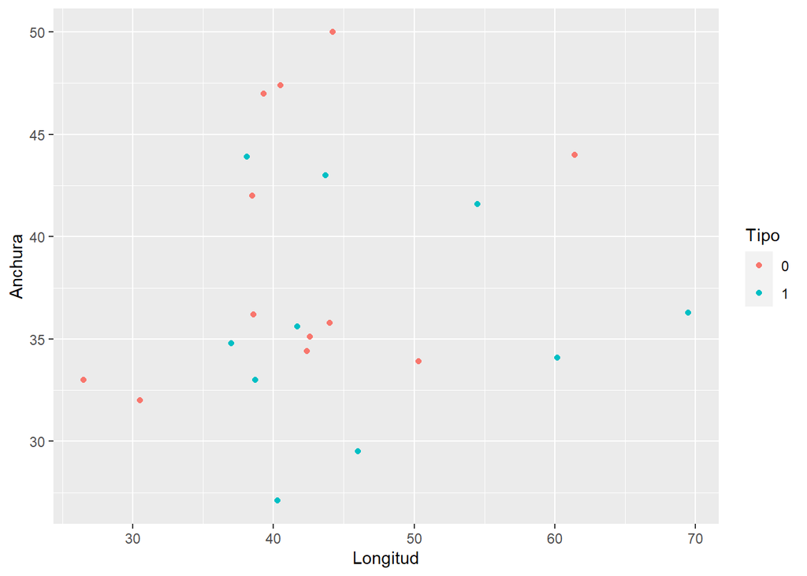

```r
library(ggplot2)
ggplot(BaseDatosFinal, aes(x = Longitud, y = Anchura, color = Tipo)) + geom_point()
```

En este gráfico de distribución donde se han utilizado las variables Anchura y Longitud podemos observar que, teniendo en cuenta que blade suele ser dos veces más largas que anchas, no se ve con claridad este característica diferenciadora. Aunque es cierto que se puede observar más “blade” con mayor longitud que “flake”.

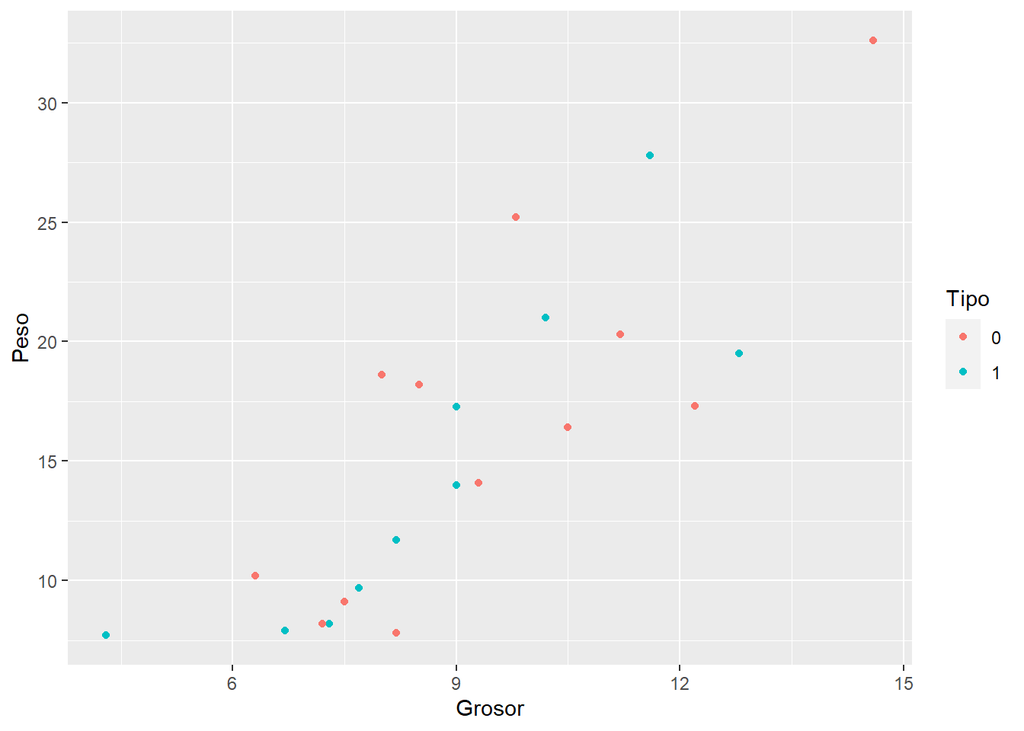

Esta gráfica de distribución donde se han utilizado las variables Peso y Grosor no aporta resultados significativos con respecto a la relación, de estas variables, con la diferenciación de “blade” o “flake”.

## Tercer Paso

Creo la variable Tipo_fac, convirtiendo con la función as.factor() la variable Tipo en un factor. Esto nos permitirá trabajar con la variable categórica de una manera adecuada, ya que será necesario para los modelos que utilizo en los siguientes pasos del trabajo.

```r
BaseDatosFinal$Tipo_fac <- as.factor(BaseDatosFinal$Tipo)
BaseDatosFinal$Tipo_fac
```

```
##  [1] 1 1 0 1 1 0 0 1 1 0 0 1 0 0 0 0 1 1 0 1 0 0
## Levels: 0 1
```

## Cuarto Paso

Llevo a cabo modelos logísticos simples para analizar y predecir la relación entre variables. Al utilizar “family = binomial()”, se establece que se está ajustando un modelo logístico binomial, adecuado para la variable binaria utilizada (Tipo_fac). Si el valor obtenido en el Valor p (Pr(>|z|)) es superior al nivel de significanza comúnmente utilizado (0.05), no habrá evidencia suficiente para afirmar que existe una relación significativa entre las variables utilizadas.

```r
model <- glm(Tipo_fac ~ Anchura, data = BaseDatosFinal, family = binomial())
summary(model)
```

```
##
## Call:
## glm(formula = Tipo_fac ~ Anchura, family = binomial(), data = BaseDatosFinal)
##
## Deviance Residuals:
##     Min       1Q   Median       3Q      Max
## -1.3357  -1.1672  -0.6951   1.1340   1.5402
##
## Coefficients:
##             Estimate Std. Error z value Pr(>|z|)
## (Intercept)  3.55500    2.97860   1.194    0.233
## Anchura     -0.09970    0.07915  -1.260    0.208
##
## (Dispersion parameter for binomial family taken to be 1)
##
##     Null deviance: 30.316  on 21  degrees of freedom
## Residual deviance: 28.562  on 20  degrees of freedom
## AIC: 32.562
##
## Number of Fisher Scoring iterations: 4
```

```r
model2 <- glm(Tipo_fac ~ Longitud, data = BaseDatosFinal, family = binomial())
summary(model2)
```

```
##
## Call:
## glm(formula = Tipo_fac ~ Longitud, family = binomial(), data = BaseDatosFinal)
##
## Deviance Residuals:
##     Min       1Q   Median       3Q      Max
## -1.5692  -1.0482  -0.7464   1.2494   1.4472
##
## Coefficients:
##             Estimate Std. Error z value Pr(>|z|)
## (Intercept) -2.89123    2.23257  -1.295    0.195
## Longitud     0.06152    0.04992   1.232    0.218
##
## (Dispersion parameter for binomial family taken to be 1)
##
##     Null deviance: 30.316  on 21  degrees of freedom
## Residual deviance: 28.580  on 20  degrees of freedom
## AIC: 32.58
##
## Number of Fisher Scoring iterations: 4
```

```r
model3 <- glm(Tipo_fac ~ Grosor, data = BaseDatosFinal, family = binomial())
summary(model3)
```

```
##
## Call:
## glm(formula = Tipo_fac ~ Grosor, family = binomial(), data = BaseDatosFinal)
##
## Deviance Residuals:
##     Min       1Q   Median       3Q      Max
## -1.2712  -1.1224  -0.8578   1.1946   1.4976
##
## Coefficients:
##             Estimate Std. Error z value Pr(>|z|)
## (Intercept)   1.1340     1.7893   0.634    0.526
## Grosor       -0.1454     0.1928  -0.754    0.451
##
## (Dispersion parameter for binomial family taken to be 1)
##
##     Null deviance: 30.316  on 21  degrees of freedom
## Residual deviance: 29.722  on 20  degrees of freedom
## AIC: 33.722
##
## Number of Fisher Scoring iterations: 4
```

```r
model4 <- glm(Tipo_fac ~ Peso, data = BaseDatosFinal, family = binomial())
summary(model4)
```

```
##
## Call:
## glm(formula = Tipo_fac ~ Peso, family = binomial(), data = BaseDatosFinal)
##
## Deviance Residuals:
##    Min      1Q  Median      3Q     Max
## -1.244  -1.080  -0.871   1.175   1.498
##
## Coefficients:
##             Estimate Std. Error z value Pr(>|z|)
## (Intercept)  0.50147    1.08366   0.463    0.644
## Peso        -0.04425    0.06496  -0.681    0.496
##
## (Dispersion parameter for binomial family taken to be 1)
##
##     Null deviance: 30.316  on 21  degrees of freedom
## Residual deviance: 29.835  on 20  degrees of freedom
## AIC: 33.835
##
## Number of Fisher Scoring iterations: 4
```

Podemos observar que ninguno de los modelos simples realizados da una relación significativa entre los parámetros arqueométricos y Tipo_fac. Esto da a entender que ninguna de esas variables por si solas son suficiente como para diferenciar los dos tipos de producción (1 y 0).

## Quinto Paso

En este caso, realizo modelos logísticos multiples. La principal diferencia con el ejercicio anterior es que se utiliza, para analizar y predecir la relación, una variable de respuesta binaria (Tipo_fac), como antes, pero ahora se utilizan múltiples variables predictoras. Al igual que en el anterior paso, el valor p obtenido en cada modelo realizado no da una relación significativa, ya que el valor p sale superior a 0.05. En algunos de los modelos en los que la Longitud no estaba junto a la variable Anchura, se puede observar que la variable Longitud está cerca de una posible relación significativa, pero no es suficiente.

```r
model_1 <- glm(Tipo_fac ~ Anchura + Longitud, data = BaseDatosFinal, family = binomial())
summary(model_1)
```

```
##
## Call:
## glm(formula = Tipo_fac ~ Anchura + Longitud, family = binomial(),
##     data = BaseDatosFinal)
##
## Deviance Residuals:
##     Min       1Q   Median       3Q      Max
## -1.4955  -0.9938  -0.5783   1.0690   1.8046
##
## Coefficients:
##             Estimate Std. Error z value Pr(>|z|)
## (Intercept)  1.15363    3.53023   0.327    0.744
## Anchura     -0.12274    0.08690  -1.412    0.158
## Longitud     0.07415    0.05280   1.404    0.160
##
## (Dispersion parameter for binomial family taken to be 1)
##
##     Null deviance: 30.316  on 21  degrees of freedom
## Residual deviance: 26.238  on 19  degrees of freedom
## AIC: 32.238
##
## Number of Fisher Scoring iterations: 4
```

```r
model_2 <- glm(Tipo_fac ~ Grosor + Peso, data = BaseDatosFinal, family = binomial())
summary(model_2)
```

```
##
## Call:
## glm(formula = Tipo_fac ~ Grosor + Peso, family = binomial(),
##     data = BaseDatosFinal)
##
## Deviance Residuals:
##     Min       1Q   Median       3Q      Max
## -1.2639  -1.1097  -0.8633   1.1852   1.4711
##
## Coefficients:
##             Estimate Std. Error z value Pr(>|z|)
## (Intercept)  1.05747    1.93214   0.547    0.584
## Grosor      -0.11697    0.33435  -0.350    0.726
## Peso        -0.01172    0.11288  -0.104    0.917
##
## (Dispersion parameter for binomial family taken to be 1)
##
##     Null deviance: 30.316  on 21  degrees of freedom
## Residual deviance: 29.711  on 19  degrees of freedom
## AIC: 35.711
##
## Number of Fisher Scoring iterations: 4
```

```r
model_3 <- glm(Tipo_fac ~ Anchura + Longitud + Grosor, data = BaseDatosFinal, family = binomial())
summary(model_3)
```

```
##
## Call:
## glm(formula = Tipo_fac ~ Anchura + Longitud + Grosor, family = binomial(),
##     data = BaseDatosFinal)
##
## Deviance Residuals:
##     Min       1Q   Median       3Q      Max
## -1.5451  -0.8894  -0.4082   0.8555   1.7736
##
## Coefficients:
##             Estimate Std. Error z value Pr(>|z|)
## (Intercept)  0.90421    3.70151   0.244   0.8070
## Anchura     -0.08133    0.09747  -0.834   0.4040
## Longitud     0.10361    0.06210   1.668   0.0952 .
## Grosor      -0.29129    0.29611  -0.984   0.3252
## ---
## Signif. codes:  0 '***' 0.001 '**' 0.01 '*' 0.05 '.' 0.1 ' ' 1
##
## (Dispersion parameter for binomial family taken to be 1)
##
##     Null deviance: 30.316  on 21  degrees of freedom
## Residual deviance: 25.163  on 18  degrees of freedom
## AIC: 33.163
##
## Number of Fisher Scoring iterations: 4
```

```r
model_4 <- glm(Tipo_fac ~ Anchura + Longitud + Grosor + Peso, data = BaseDatosFinal, family = binomial())
summary(model_4)
```

```
##
## Call:
## glm(formula = Tipo_fac ~ Anchura + Longitud + Grosor + Peso,
##     family = binomial(), data = BaseDatosFinal)
##
## Deviance Residuals:
##     Min       1Q   Median       3Q      Max
## -1.6405  -0.9275  -0.3791   0.8022   1.8544
##
## Coefficients:
##             Estimate Std. Error z value Pr(>|z|)
## (Intercept)  4.18851    8.15601   0.514    0.608
## Anchura     -0.15950    0.20170  -0.791    0.429
## Longitud     0.08578    0.07151   1.200    0.230
## Grosor      -0.44733    0.45570  -0.982    0.326
## Peso         0.11868    0.26109   0.455    0.649
##
## (Dispersion parameter for binomial family taken to be 1)
##
##     Null deviance: 30.316  on 21  degrees of freedom
## Residual deviance: 24.955  on 17  degrees of freedom
## AIC: 34.955
##
## Number of Fisher Scoring iterations: 4
```

```r
model_5 <- glm(Tipo_fac ~ Longitud + Grosor + Peso, data = BaseDatosFinal, family = binomial())
summary(model_5)
```

```
##
## Call:
## glm(formula = Tipo_fac ~ Longitud + Grosor + Peso, family = binomial(),
##     data = BaseDatosFinal)
##
## Deviance Residuals:
##     Min       1Q   Median       3Q      Max
## -1.6067  -0.9244  -0.4791   1.0154   1.6226
##
## Coefficients:
##             Estimate Std. Error z value Pr(>|z|)
## (Intercept) -2.01949    2.81717  -0.717   0.4735
## Longitud     0.11605    0.06500   1.785   0.0742 .
## Grosor      -0.25014    0.38545  -0.649   0.5164
## Peso        -0.06689    0.12955  -0.516   0.6056
## ---
## Signif. codes:  0 '***' 0.001 '**' 0.01 '*' 0.05 '.' 0.1 ' ' 1
##
## (Dispersion parameter for binomial family taken to be 1)
##
##     Null deviance: 30.316  on 21  degrees of freedom
## Residual deviance: 25.627  on 18  degrees of freedom
## AIC: 33.627
##
## Number of Fisher Scoring iterations: 4
```

```r
model_6 <- glm(Tipo_fac ~ Longitud + Grosor, data = BaseDatosFinal, family = binomial())
summary(model_6)
```

```
##
## Call:
## glm(formula = Tipo_fac ~ Longitud + Grosor, family = binomial(),
##     data = BaseDatosFinal)
##
## Deviance Residuals:
##     Min       1Q   Median       3Q      Max
## -1.7960  -0.9758  -0.4889   1.0784   1.5460
##
## Coefficients:
##             Estimate Std. Error z value Pr(>|z|)
## (Intercept) -1.43290    2.49032  -0.575   0.5650
## Longitud     0.10906    0.06238   1.748   0.0804 .
## Grosor      -0.39519    0.27284  -1.448   0.1475
## ---
## Signif. codes:  0 '***' 0.001 '**' 0.01 '*' 0.05 '.' 0.1 ' ' 1
##
## (Dispersion parameter for binomial family taken to be 1)
##
##     Null deviance: 30.316  on 21  degrees of freedom
## Residual deviance: 25.898  on 19  degrees of freedom
## AIC: 31.898
##
## Number of Fisher Scoring iterations: 4
```

```r
model_7 <- glm(Tipo_fac ~ Longitud + Peso, data = BaseDatosFinal, family = binomial())
summary(model_7)
```

```
##
## Call:
## glm(formula = Tipo_fac ~ Longitud + Peso, family = binomial(),
##     data = BaseDatosFinal)
##
## Deviance Residuals:
##     Min       1Q   Median       3Q      Max
## -1.3950  -0.9716  -0.5517   1.0159   1.6568
##
## Coefficients:
##             Estimate Std. Error z value Pr(>|z|)
## (Intercept) -3.10468    2.40497  -1.291   0.1967
## Longitud     0.11173    0.06606   1.691   0.0908 .
## Peso        -0.12926    0.08981  -1.439   0.1501
## ---
## Signif. codes:  0 '***' 0.001 '**' 0.01 '*' 0.05 '.' 0.1 ' ' 1
##
## (Dispersion parameter for binomial family taken to be 1)
##
##     Null deviance: 30.316  on 21  degrees of freedom
## Residual deviance: 26.067  on 19  degrees of freedom
## AIC: 32.067
##
## Number of Fisher Scoring iterations: 3
```

## Sexto Paso

En este paso creo la variable proporción longitud/anchura, ya que en principio, debería ser la que más sentido arqueológico tiene, ya que como he mencionado en la introducción, las laminas (“blade”) suelen ser más largas que anchas, a diferencia de las lascas (“flake”).

```r
BaseDatosFinal$Longitud_Anchura <- BaseDatosFinal$Longitud/BaseDatosFinal$Anchura
```

## Septimo Paso

Volvemos a realizar un modelo logístico simple, pero esta vez con la nueva variable creada. Vemos que el valor AIC obtenido es el más bajo hasta el momento, por lo que indica un mejor ajuste del modelo.

```r
model5 <- glm(Tipo_fac ~ Longitud_Anchura, data = BaseDatosFinal, family = binomial())
summary(model5)
```

```
##
## Call:
## glm(formula = Tipo_fac ~ Longitud_Anchura, family = binomial(),
##     data = BaseDatosFinal)
##
## Deviance Residuals:
##     Min       1Q   Median       3Q      Max
## -1.5339  -0.9024  -0.6563   1.0267   1.7393
##
## Coefficients:
##                  Estimate Std. Error z value Pr(>|z|)
## (Intercept)        -4.183      2.209  -1.894   0.0582 .
## Longitud_Anchura    3.364      1.829   1.839   0.0660 .
## ---
## Signif. codes:  0 '***' 0.001 '**' 0.01 '*' 0.05 '.' 0.1 ' ' 1
##
## (Dispersion parameter for binomial family taken to be 1)
##
##     Null deviance: 30.316  on 21  degrees of freedom
## Residual deviance: 25.947  on 20  degrees of freedom
## AIC: 29.947
##
## Number of Fisher Scoring iterations: 4
```

## Octavo Paso

Realizamos modelos logísticos multiples, uno con el peso y el otro con el grosor.

```r
model_8 <- glm(Tipo_fac ~ Longitud_Anchura + Peso, data = BaseDatosFinal, family = binomial())
summary(model_8)
```

```
##
## Call:
## glm(formula = Tipo_fac ~ Longitud_Anchura + Peso, family = binomial(),
##     data = BaseDatosFinal)
##
## Deviance Residuals:
##     Min       1Q   Median       3Q      Max
## -1.5063  -0.9923  -0.5654   1.0482   1.7747
##
## Coefficients:
##                  Estimate Std. Error z value Pr(>|z|)
## (Intercept)      -3.50068    2.45399  -1.427   0.1537
## Longitud_Anchura  3.33227    1.83824   1.813   0.0699 .
## Peso             -0.04251    0.07152  -0.594   0.5523
## ---
## Signif. codes:  0 '***' 0.001 '**' 0.01 '*' 0.05 '.' 0.1 ' ' 1
##
## (Dispersion parameter for binomial family taken to be 1)
##
##     Null deviance: 30.316  on 21  degrees of freedom
## Residual deviance: 25.581  on 19  degrees of freedom
## AIC: 31.581
##
## Number of Fisher Scoring iterations: 4
```

```r
model_9 <- glm(Tipo_fac ~ Longitud_Anchura + Grosor, data = BaseDatosFinal, family = binomial())
summary(model_9)
```

```
##
## Call:
## glm(formula = Tipo_fac ~ Longitud_Anchura + Grosor, family = binomial(),
##     data = BaseDatosFinal)
##
## Deviance Residuals:
##     Min       1Q   Median       3Q      Max
## -1.3929  -0.8988  -0.4202   0.7961   1.8027
##
## Coefficients:
##                  Estimate Std. Error z value Pr(>|z|)
## (Intercept)       -2.3634     2.6801  -0.882   0.3779
## Longitud_Anchura   3.6912     1.8852   1.958   0.0502 .
## Grosor            -0.2495     0.2371  -1.053   0.2926
## ---
## Signif. codes:  0 '***' 0.001 '**' 0.01 '*' 0.05 '.' 0.1 ' ' 1
##
## (Dispersion parameter for binomial family taken to be 1)
##
##     Null deviance: 30.316  on 21  degrees of freedom
## Residual deviance: 24.698  on 19  degrees of freedom
## AIC: 30.698
##
## Number of Fisher Scoring iterations: 4
```

## Noveno Paso

Con los códigos utilizados en esta parte podemos calcular la media de los valores de la columna Longitud_Anchura, en correspondencia a las filas en las que el valor coincida con 0 (primer código) o 1 (segundo código) de la columna Tipo.

Esto se debe a que cuanto más cerca esté el resultado de la media a 1, puede significar que la relación ancho y longitud sea más cercana a una proporción de 1:1.

```r
mean(BaseDatosFinal$Longitud_Anchura [BaseDatosFinal$Tipo == "0"])
```

```
## [1] 1.072353
```

```r
mean(BaseDatosFinal$Longitud_Anchura [BaseDatosFinal$Tipo == "1"])
```

```
## [1] 1.332795
```

## Decimo Paso

Llevo a cabo el test t para asegurar los resultados obtenidos con anterioridad, es decir, confirmar la diferencia entre 1 y 0. Fijandome en el p-value llego a la conclusión de que en “1” al ser el p-value inferior a 0.05 hay una diferencia significativa entre las medidas de anchura y longitud. Mientras que en el “0” el p-value es mayor a 0.05 y por lo tanto no hay diferencia en las medidas de anchura y longitud. Esto confirma los resultados del paso anterior.

```r
t.test(BaseDatosFinal$Anchura[BaseDatosFinal$Tipo == "1"], BaseDatosFinal$Longitud[BaseDatosFinal$Tipo == "1"])
```

```
##
##  Welch Two Sample t-test
##
## data:  BaseDatosFinal$Anchura[BaseDatosFinal$Tipo == "1"] and BaseDatosFinal$Longitud[BaseDatosFinal$Tipo == "1"]
## t = -2.8628, df = 13.388, p-value = 0.013
## alternative hypothesis: true difference in means is not equal to 0
## 95 percent confidence interval:
##  -19.416671  -2.743329
## sample estimates:
## mean of x mean of y
##     35.89     46.97
```

```r
t.test(BaseDatosFinal$Anchura[BaseDatosFinal$Tipo == "0"], BaseDatosFinal$Longitud[BaseDatosFinal$Tipo == "0"])
```

```
##
##  Welch Two Sample t-test
##
## data:  BaseDatosFinal$Anchura[BaseDatosFinal$Tipo == "0"] and BaseDatosFinal$Longitud[BaseDatosFinal$Tipo == "0"]
## t = -0.73995, df = 20.098, p-value = 0.4679
## alternative hypothesis: true difference in means is not equal to 0
## 95 percent confidence interval:
##  -8.909100  4.242434
## sample estimates:
## mean of x mean of y
##  39.23333  41.56667
```

## Conclusión

Para confirmar que en “blade” se observaba una diferencia entre longitud y anchura llevé a cabo un test t, el cual confirmó mis resultados.

Por tanto, diría que el principal parámetro arqueométrico que permite diferenciar los “flake” de los “blade” es la Longitud, siendo significativo solo para los “blade”, en mi caso se hace más claro con la proporción longitud/anchura.

## Fuentes

https://www.rdocumentation.org/

https://community.rstudio.com/

https://www.r-bloggers.com/